# Practical: Residuals and autocorrelation

## Residual patterns in surveillance data

## Expected learning outcomes

By the end of this session, participants should be able to:

- assess model fit and assumptions after accounting for trend and periodicity in surveillance data
- identify remaining periodicity
- detect autocorrelation in the residuals of models on surveillance data
- assess whether including lagged counts in regression models reduces autocorrelation

## Task 1

*Start by fitting the negative binomial model with a trend and two pairs of sines and cosines (52- and 26-week periods), as in the Periodicity practical.*

*Assess the model assumptions and check for any remaining patterns in the residuals.*

```r
load(here("data","mort_period.RData"))

# Fit the negative binomial model from the Periodicity practical.
mort_trendsin2cos2_nb <- MASS::glm.nb(
    cases ~ index + sin52 + cos52 + sin26 + cos26,
    data = mort_period
)
```

Calculate and plot the deviance residuals from the model.

```r
mort_res <- mort_period %>%
    mutate(
        res = residuals(mort_trendsin2cos2_nb,
                        type = "deviance")
    )
```

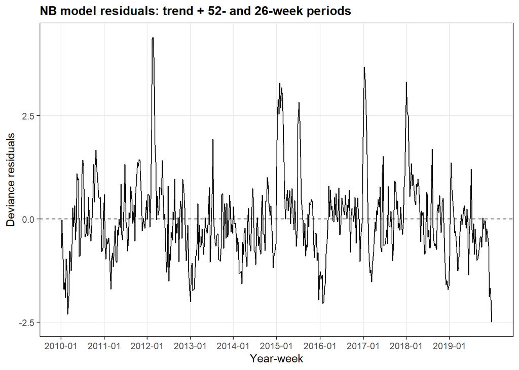

```r
max.index <- max(mort_res$index)

ggplot(data = mort_res) +
    geom_line(
        mapping = aes(x = date_index, y = res)
    ) +
    geom_hline(yintercept = 0, linetype = "dashed") +
    scale_x_yearweek(
        breaks = tsibble::yearweek(paste0(2010:2019, " W01")),
        labels = paste0(2010:2019, "-01")
    ) +
    labs(
        x = "Year-week",
        y = "Deviance residuals",
        title = "NB model residuals: trend + 52- and 26-week periods"
    ) +
    tsa_theme
```

*Examine the residuals against time. Do you see any remaining patterns?*

Do you consider this model appropriate?

## Task 2

*Is there any remaining periodicity that can be observed in the residuals?*

To assess remaining periodicity in the data, we can produce a periodogram of the residuals (use code from the Periodicity practical).

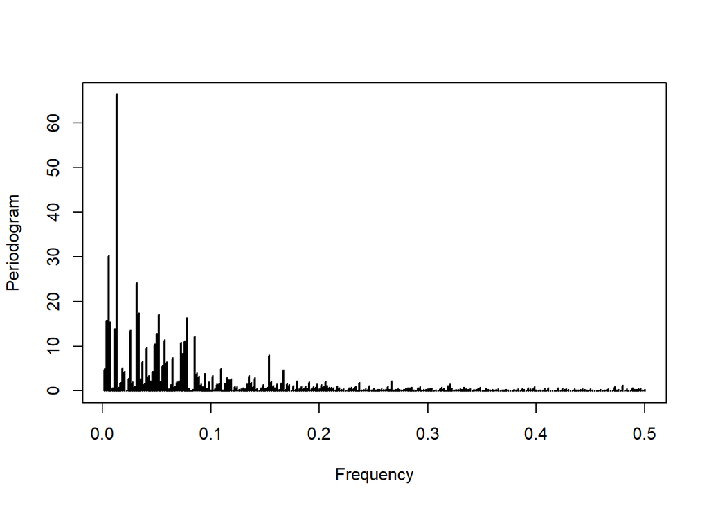

```r
mort_residual_period <- TSA::periodogram(mort_res$res)
```

```r
mort_residual_period_recip <-
    tibble(
        freq = mort_residual_period$freq,
        spec = mort_residual_period$spec
    ) %>%
    arrange(desc(spec)) %>%
    mutate(reciprocal_freq = 1 / freq)  # period in weeks

head(mort_residual_period_recip, 10)
```

```
# A tibble: 10 × 3
      freq  spec reciprocal_freq
     <dbl> <dbl>           <dbl>
 1 0.0130   66.3            77.1
 2 0.00556  30.2           180
 3 0.0315   24.1            31.8
 4 0.0333   17.4            30
 5 0.0519   17.2            19.3
 6 0.0778   16.3            12.9
 7 0.00370  15.7           270
 8 0.00741  15.3           135
 9 0.0111   13.8            90
10 0.0259   13.5            38.6
```

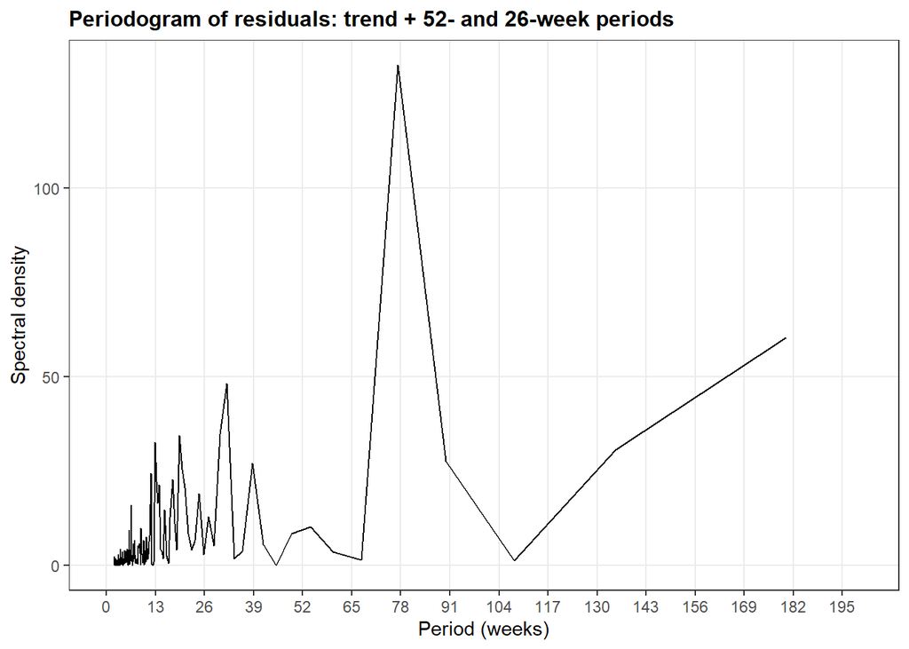

```r
# Breaks every 13 weeks, approximately 3 months
ggplot(data = mort_residual_period_recip, aes(x = reciprocal_freq, y = 2*spec)) +
    geom_line() +
    scale_x_continuous(limits = c(0, 200), breaks=seq(0, 200, 13)) +
    labs(x = "Period (weeks)",
         y = "Spectral density",
         title="Periodogram of residuals: trend + 52- and 26-week periods") +
    tsa_theme
```

*Which periods stand out in the periodogram?*

*Does the periodicity make sense from an epidemiological perspective?*

The periodogram of the residuals shows a strong peak at around 77 weeks. We will explore a 78-week period, corresponding to approximately one and a half years, to assess whether this additional periodic component improves the model fit.

Generate sine and cosine terms for a 78-week period and add them to the previous negative binomial regression model.

```r
# Calculate the sine and cosine terms for a 78-week period
mort_period <- mort_period %>%
    mutate(
        sin78 = sin(2 * pi * index / 78),
        cos78 = cos(2 * pi * index / 78)
    )

# Fit the negative binomial model with three pairs of sine and cosine terms
mort_trendsin3cos3_nb <- MASS::glm.nb(
    cases ~ index + sin52 + cos52 + sin26 + cos26 + sin78 + cos78,
    data = mort_period
)
```

As in the Periodicity practical, we use the likelihood ratio test (LRT) to assess whether adding the new sine and cosine terms improves the model fit.

Remember that the two models must be nested and fitted to the same observations.

```r
# Check the number of observations in both models
nobs(mort_trendsin2cos2_nb)
```

```
[1] 521
```

```r
nobs(mort_trendsin3cos3_nb)
```

```
[1] 521
```

```r
# Compare the two nested models
lrtest(mort_trendsin2cos2_nb, mort_trendsin3cos3_nb)
```

```
Likelihood ratio test

Model 1: cases ~ index + sin52 + cos52 + sin26 + cos26
Model 2: cases ~ index + sin52 + cos52 + sin26 + cos26 + sin78 + cos78
  #Df  LogLik Df  Chisq Pr(>Chisq)
1   7 -3866.1
2   9 -3829.2  2 73.816  < 2.2e-16 ***
---
Signif. codes:  0 '***' 0.001 '**' 0.01 '*' 0.05 '.' 0.1 ' ' 1
```

Does adding the sine and cosine terms for the 78-week period improve the model fit?

Does a statistically significant result mean that the model is now appropriate?

An improvement in model fit does not necessarily mean that the model is appropriate. We should also examine the residuals.

*Calculate the deviance residuals from the new model and compare them with those from the previous model.*

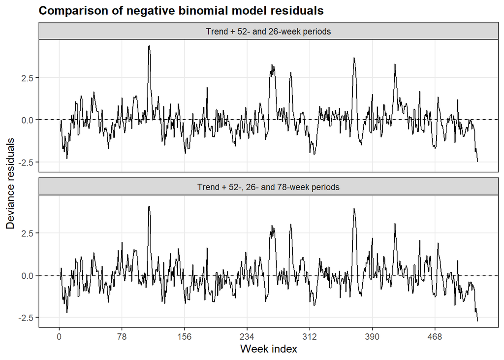

```r
mort_res <- mort_res %>%
    mutate(
        res3_nb = residuals(mort_trendsin3cos3_nb,
                         type = "deviance")
    )

mort_res %>%
    pivot_longer(
        cols = c(res, res3_nb),
        names_to = "model",
        values_to = "residuals"
    ) %>%
    mutate(
        model = factor(
            model,
            levels = c("res", "res3_nb"),
            labels = c(
                "Trend + 52- and 26-week periods",
                "Trend + 52-, 26- and 78-week periods"
            )
        )
    ) %>%
    ggplot(aes(x = index, y = residuals)) +
    geom_line() +
    geom_hline(yintercept = 0, linetype = "dashed") +
    facet_wrap(~model, ncol = 1) +
    scale_x_continuous(
        limits = c(0, max.index),
        breaks = seq(0, max.index, 78)
    ) +
    labs(
        x = "Week index",
        y = "Deviance residuals",
        title = "Comparison of negative binomial model residuals"
    ) +
    tsa_theme
```

Compare the residuals from the two models. Are there still temporal patterns?

### Optional exercise

*Produce a periodogram of the residuals from the new model and compare it with the previous periodogram.*

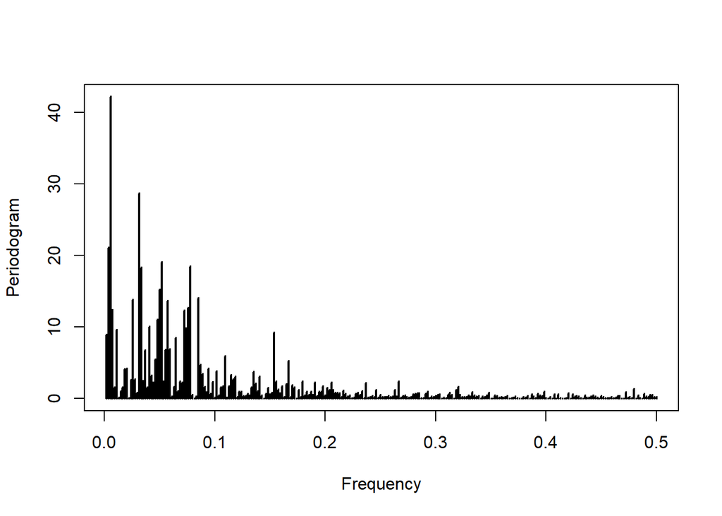

```r
mort_residual_period3 <- TSA::periodogram(mort_res$res3_nb)
```

```r
mort_residual_period3_recip <-
    tibble(
        freq = mort_residual_period3$freq,
        spec = mort_residual_period3$spec
    ) %>%
    arrange(desc(spec)) %>%
    mutate(reciprocal_freq = 1 / freq)  # period in weeks

head(mort_residual_period3_recip, 10)
```

```
# A tibble: 10 × 3
      freq  spec reciprocal_freq
     <dbl> <dbl>           <dbl>
 1 0.00556  42.2           180
 2 0.0315   28.7            31.8
 3 0.00370  21.1           270
 4 0.0519   19.1            19.3
 5 0.0778   18.5            12.9
 6 0.0333   18.4            30
 7 0.05     15.3            20
 8 0.0852   14.1            11.7
 9 0.0259   13.8            38.6
10 0.0574   13.7            17.4
```

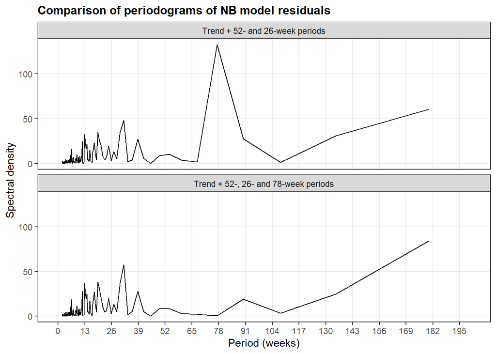

```r
bind_rows(
    mort_residual_period_recip %>%
        mutate(model = "Trend + 52- and 26-week periods"),
    mort_residual_period3_recip %>%
        mutate(model = "Trend + 52-, 26- and 78-week periods")
) %>%
    ggplot(aes(x = reciprocal_freq, y = 2*spec)) +
    geom_line() +
    facet_wrap(~model, ncol = 1) +
    scale_x_continuous(
        limits = c(0, 200),
        breaks = seq(0, 200, 13)
    ) +
    labs(
        x = "Period (weeks)",
        y = "Spectral density",
        title = "Comparison of periodograms of NB model residuals"
    ) +
    tsa_theme
```

Has the inclusion of the 78-week period reduced the remaining periodicity?

Would you consider adding further sine and cosine terms? Discuss the epidemiological relevance.

## Task 3

*Check for remaining autocorrelation in the model residuals.*

Although the negative binomial model accounts for overdispersion, autocorrelation may still be present in the residuals.

Plot the autocorrelation function (ACF) of the residuals for lags up to 52 weeks.

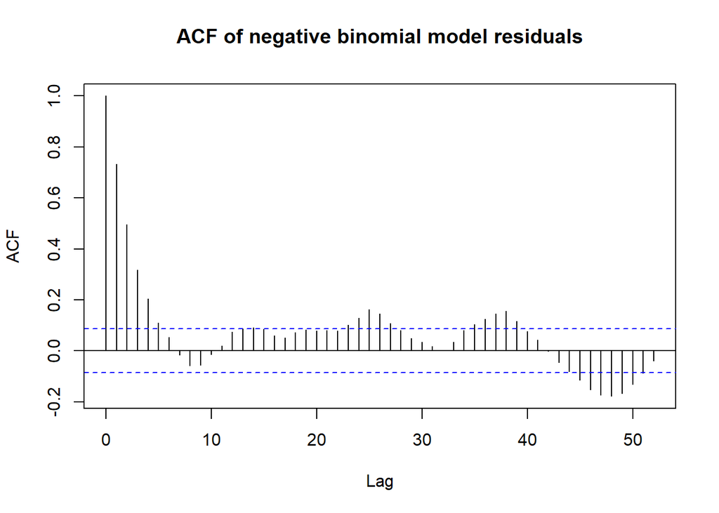

```r
# ACF of the negative binomial model residuals
stats::acf(
    mort_res$res3_nb,
    lag.max = 52,
    main = "ACF of negative binomial model residuals"
)
```

Lag 0 is always 1. Lag 1 shows the correlation between residuals one week apart, lag 2 two weeks apart, and so on.

The blue dashed lines represent approximate 95% confidence limits under the assumption of no autocorrelation. In the absence of autocorrelation, most values beyond lag zero are expected to fall within these limits.

Is there evidence of remaining autocorrelation in the negative binomial model residuals?

At which lags do you observe autocorrelation?

### Optional exercise

The Ljung–Box test assesses autocorrelation across several lags simultaneously.

```r
Box.test(mort_res$res3_nb, lag = 52, type = "Ljung-Box")
```

```
    Box-Ljung test

data:  mort_res$res3_nb
X-squared = 734.73, df = 52, p-value < 2.2e-16
```

*Are the results consistent with the ACF plot?*

## Task 4

The ACF plot suggests remaining autocorrelation at several lags. We will add lagged counts to the negative binomial model and assess whether they improve the model fit.

```r
mort_period <- mort_period %>%
    arrange(index) %>%
    mutate(
        lag1 = dplyr::lag(cases, n = 1),
        lag2 = dplyr::lag(cases, n = 2),
        lag3 = dplyr::lag(cases, n = 3),
        lag4 = dplyr::lag(cases, n = 4),
        lag5 = dplyr::lag(cases, n = 5)
    )

head(as.data.frame(mort_period), 10)
```

```
   cases_m cases_f cases year week      pop    pop_f    pop_m date_index index
1     4207    4019  8226 2010    1 46486621 23504349 22982272   2010 W01     1
2     4409    4264  8673 2010    2 46486621 23504349 22982272   2010 W02     2
3     4229    4122  8351 2010    3 46486621 23504349 22982272   2010 W03     3
4     4252    3837  8089 2010    4 46486621 23504349 22982272   2010 W04     4
5     4196    3976  8172 2010    5 46486621 23504349 22982272   2010 W05     5
6     4127    3854  7981 2010    6 46486621 23504349 22982272   2010 W06     6
7     4294    4028  8322 2010    7 46486621 23504349 22982272   2010 W07     7
8     4121    3968  8089 2010    8 46486621 23504349 22982272   2010 W08     8
9     3824    3687  7511 2010    9 46486621 23504349 22982272   2010 W09     9
10    3921    3612  7533 2010   10 46486621 23504349 22982272   2010 W10    10
   mortality_rate     cos52     sin52     sin26      cos26      sin78     cos78
1        17.69541 0.9927089 0.1205367 0.2393157  0.9709418 0.08046657 0.9967573
2        18.65698 0.9709418 0.2393157 0.4647232  0.8854560 0.16041128 0.9870503
3        17.96431 0.9350162 0.3546049 0.6631227  0.7485107 0.23931566 0.9709418
```

[output cut: 18 more lines]

Lag 1 contains the number of deaths in the previous week, lag 2 two weeks earlier, and so on. Creating lagged variables introduces missing values at the beginning of the time series.

To compare models using the likelihood ratio test (LRT), all models must be fitted to the same observations.

As we will investigate up to five lags in the optional exercise, we exclude the first five observations.

```r
# Create a common dataset for model comparison.
mort_lag <- mort_period %>%
    drop_na(lag1, lag2, lag3, lag4, lag5)

# Compare the number of observations.
nrow(mort_period)
```

```
[1] 521
```

```r
nrow(mort_lag)
```

```
[1] 516
```

Refit the negative binomial regression model without lagged terms using the reduced dataset.

```r
mort_nb_lag0 <- MASS::glm.nb(
    cases ~ index + sin52 + cos52 + sin26 + cos26 + sin78 + cos78,
    data = mort_lag
)
```

*Add the number of deaths in the previous week (lag 1) to the model. Use the likelihood ratio test to assess whether including this variable improves the model fit.*

```r
mort_nb_lag1 <- MASS::glm.nb(
    cases ~ index + sin52 + cos52 + sin26 + cos26 + sin78 + cos78 +
        lag1,
    data = mort_lag
)

# Compare the models with and without lag 1.
lrtest(mort_nb_lag0, mort_nb_lag1)
```

```
Likelihood ratio test

Model 1: cases ~ index + sin52 + cos52 + sin26 + cos26 + sin78 + cos78
Model 2: cases ~ index + sin52 + cos52 + sin26 + cos26 + sin78 + cos78 +
    lag1
  #Df  LogLik Df  Chisq Pr(>Chisq)
1   9 -3792.3
2  10 -3567.5  1 449.63  < 2.2e-16 ***
---
Signif. codes:  0 '***' 0.001 '**' 0.01 '*' 0.05 '.' 0.1 ' ' 1
```

*Does including lag 1 improve the model fit?*

*Add lag 2 to the model that already includes lag 1.*

```r
mort_nb_lag2 <- MASS::glm.nb(
    cases ~ index + sin52 + cos52 + sin26 + cos26 + sin78 + cos78 +
        lag1 + lag2,
    data = mort_lag
)

# Assess the additional contribution of lag 2.
lrtest(mort_nb_lag1, mort_nb_lag2)
```

```
Likelihood ratio test

Model 1: cases ~ index + sin52 + cos52 + sin26 + cos26 + sin78 + cos78 +
    lag1
Model 2: cases ~ index + sin52 + cos52 + sin26 + cos26 + sin78 + cos78 +
    lag1 + lag2
  #Df  LogLik Df  Chisq Pr(>Chisq)
1  10 -3567.5
2  11 -3560.8  1 13.378  0.0002546 ***
---
Signif. codes:  0 '***' 0.001 '**' 0.01 '*' 0.05 '.' 0.1 ' ' 1
```

*Does including lag 2 further improve the model fit?*

### Optional exercise

*Repeat the previous steps for lags 3, 4 and 5. Compare each model with the previous model.*

```r
# Add lag 3.
mort_nb_lag3 <- MASS::glm.nb(
    cases ~ index + sin52 + cos52 + sin26 + cos26 + sin78 + cos78 +
        lag1 + lag2 + lag3,
    data = mort_lag
)

lrtest(mort_nb_lag2, mort_nb_lag3)
```

```
Likelihood ratio test

Model 1: cases ~ index + sin52 + cos52 + sin26 + cos26 + sin78 + cos78 +
    lag1 + lag2
Model 2: cases ~ index + sin52 + cos52 + sin26 + cos26 + sin78 + cos78 +
    lag1 + lag2 + lag3
  #Df  LogLik Df  Chisq Pr(>Chisq)
1  11 -3560.8
2  12 -3560.4  1 0.9027     0.3421
```

```r
# Add lag 4.
mort_nb_lag4 <- MASS::glm.nb(
    cases ~ index + sin52 + cos52 + sin26 + cos26 + sin78 + cos78 +
        lag1 + lag2 + lag3 + lag4,
    data = mort_lag
)

lrtest(mort_nb_lag3, mort_nb_lag4)
```

```
Likelihood ratio test

Model 1: cases ~ index + sin52 + cos52 + sin26 + cos26 + sin78 + cos78 +
    lag1 + lag2 + lag3
Model 2: cases ~ index + sin52 + cos52 + sin26 + cos26 + sin78 + cos78 +
    lag1 + lag2 + lag3 + lag4
  #Df  LogLik Df  Chisq Pr(>Chisq)
1  12 -3560.4
2  13 -3560.3  1 0.2556     0.6131
```

```r
# Add lag 5.
mort_nb_lag5 <- MASS::glm.nb(
    cases ~ index + sin52 + cos52 + sin26 + cos26 + sin78 + cos78 +
        lag1 + lag2 + lag3 + lag4 + lag5,
    data = mort_lag
)

lrtest(mort_nb_lag4, mort_nb_lag5)
```

```
Likelihood ratio test

Model 1: cases ~ index + sin52 + cos52 + sin26 + cos26 + sin78 + cos78 +
    lag1 + lag2 + lag3 + lag4
Model 2: cases ~ index + sin52 + cos52 + sin26 + cos26 + sin78 + cos78 +
    lag1 + lag2 + lag3 + lag4 + lag5
  #Df  LogLik Df  Chisq Pr(>Chisq)
1  13 -3560.3
2  14 -3560.1  1 0.3621     0.5474
```

*Based on the likelihood ratio tests, how many lags would you include in the model?*

## Task 5

Assess whether including lagged counts has reduced autocorrelation in the residuals.

```r
mort_lag <- mort_lag %>%
    mutate(
        res_nb_lag0 = residuals(mort_nb_lag0,
                               type = "deviance"),
        res_nb_lag2 = residuals(mort_nb_lag2,
                               type = "deviance")
    )
```

*Compare the ACF of the residuals from the models with and without lagged counts.*

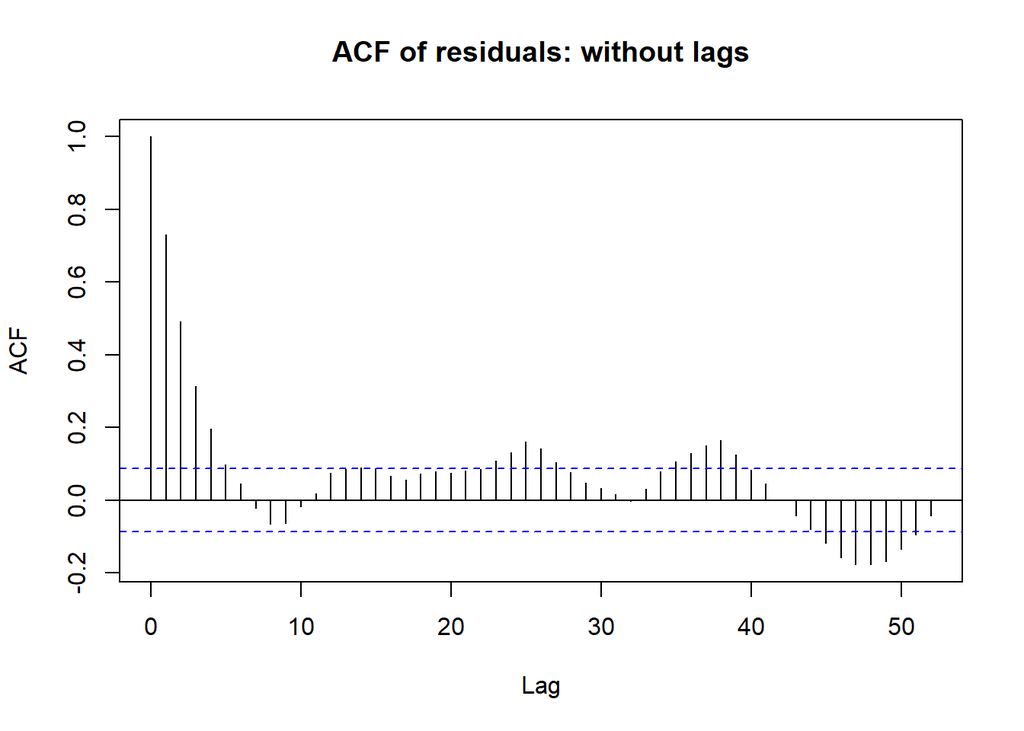

```r
stats::acf(
    mort_lag$res_nb_lag0,
    lag.max = 52,
    main = "ACF of residuals: without lags"
)
```

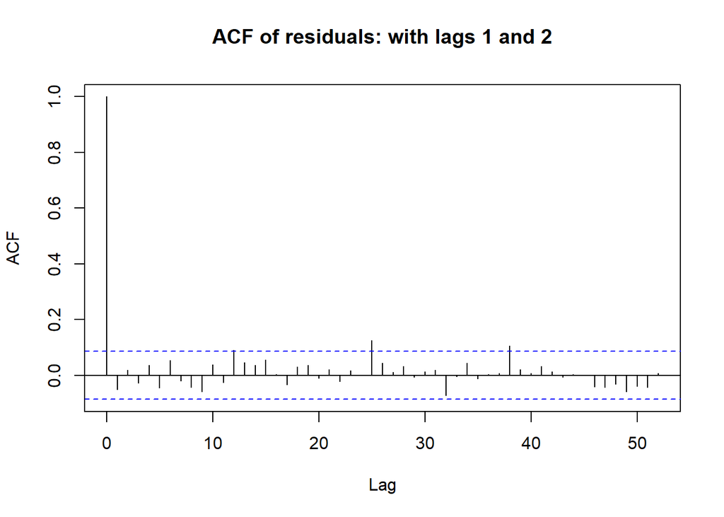

```r
stats::acf(
    mort_lag$res_nb_lag2,
    lag.max = 52,
    main = "ACF of residuals: with lags 1 and 2"
)
```

Has including lagged counts reduced autocorrelation in the residuals?

Is there still evidence of autocorrelation?

### Optional exercise

*Compare the residuals from the models with and without lagged counts.*

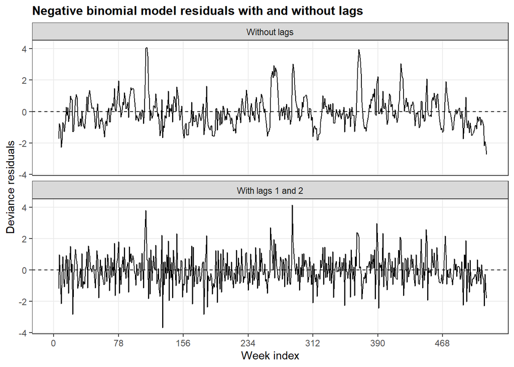

```r
mort_lag %>%
    pivot_longer(
        cols = c(res_nb_lag0, res_nb_lag2),
        names_to = "model",
        values_to = "residuals"
    ) %>%
    mutate(
        model = factor(
            model,
            levels = c("res_nb_lag0", "res_nb_lag2"),
            labels = c("Without lags", "With lags 1 and 2")
        )
    ) %>%
    ggplot(aes(x = index, y = residuals)) +
    geom_line() +
    geom_hline(yintercept = 0, linetype = "dashed") +
    facet_wrap(~model, ncol = 1) +
    scale_x_continuous(
        limits = c(0, max.index),
        breaks = seq(0, max.index, 78)
    ) +
    labs(
        x = "Week index",
        y = "Deviance residuals",
        title = "Negative binomial model residuals with and without lags"
    ) +
    tsa_theme
```

## Task 6 (Optional)

*Repeat the analysis separately for men and women. Do you observe similar patterns?*

```r
# save(mort_res, file = here("data", "mort_res.RData"))

# load(here("data","mort_res.RData"))
```